# Decomposition of Role structures

Algebraic analysis of complex social networks* Networks 2021 Conference – Workshop 8 (part 4)

Antonio Rivero Ostoic

Sch Culture & Soc, Aarhus University

jaro@cas.au.dk

24 June 2021

Semigroups representing social networks are huge structures that needs reduction to facilitate analysis, even if they represent Role structures.

Package `"multiplex"` has two functions to perform semigroup decomposition:

- `fact()` is for the *factorization* of partially ordered semigroups
- `cngr()` is to find *congruence relations* in abstract semigroups

## Factorization

Decomposition of partially ordered semigroups via factorization uses the multiplication and partial order tables representing the network role structure. The Role structure in `S_A` is constructed from the network positional system, which are the semigroup generators.

```r
# semigroup
S_A
```

```
$dim
[1] 4

$gens
, , C

     [,1] [,2] [,3] [,4]
[1,]    1    0    1    0
[2,]    0    1    1    0
[3,]    1    0    1    0
[4,]    0    0    0    1

, , F

     [,1] [,2] [,3] [,4]
[1,]    1    0    1    0
[2,]    1    1    1    0
[3,]    1    0    1    0
[4,]    0    0    0    1

, , K

     [,1] [,2] [,3] [,4]
[1,]    1    0    1    0
[2,]    0    1    0    0
[3,]    0    0    1    0
[4,]    0    0    0    0

, , A

     [,1] [,2] [,3] [,4]
[1,]    1    0    0    0
[2,]    0    1    0    0
[3,]    0    0    1    0
[4,]    0    0    0    1

, , D

     [,1] [,2] [,3] [,4]
[1,]    1    0    1    0
```

[output cut: 37 more lines]

```
CD   CD  CD CKD  CD  CD  CD CKD CKD  CD CKD CKD CKD  CD  CD CKD  CD CKD CKD CKD CKD
CL   CL  CL  CL  CL CKD CKD  CL  CL CKD  CL CKD  CL CKD CKD CKD CKD CKD CKD CKD CKD
KD  KDC CKD  KD  KD  KD  KD  KD KDC CKD CKD  KD  KD KDC CKD  KD KDC CKD KDC KDC CKD
KL   CK  CL  KL  KL  KD  KD  KL  CK CKD  CL  KD  KL KDC CKD  KD KDC CKD KDC KDC CKD
DC   DF  DF DCK  DC  CD  CD DCL DCL  CD DCL CKD DCL  CD  CD CKD  CD CKD CKD CKD CKD
DF   DF  DF DCL  DF  CD  CD DCL DCL  CD DCL CKD DCL  CD  CD CKD  CD CKD CKD CKD CKD
DK  DCK DCL  DK  DK  KD  KD  DK DCK CKD DCL  KD  DK KDC CKD  KD KDC CKD KDC KDC CKD
GC   CD  CD KDC  GC  CD  CD CKD CKD  CD CKD CKD CKD  CD  CD CKD  CD CKD CKD CKD CKD
CKD CKD CKD CKD CKD CKD CKD CKD CKD CKD CKD CKD CKD CKD CKD CKD CKD CKD CKD CKD CKD
KDC CKD CKD KDC KDC CKD CKD CKD CKD CKD CKD CKD CKD CKD CKD CKD CKD CKD CKD CKD CKD
DCK DCL DCL DCK DCK CKD CKD DCL DCL CKD DCL CKD DCL CKD CKD CKD CKD CKD CKD CKD CKD
DCL DCL DCL DCL DCL CKD CKD DCL DCL CKD DCL CKD DCL CKD CKD CKD CKD CKD CKD CKD CKD

attr(,"class")
[1] "Semigroup" "symbolic"
```

The partial order table represents a hierarchy among string relations.

```r
# partial order
P_A
```

```
    C F K A D G L CK CD CL KD KL DC DF DK GC CKD KDC DCK DCL
C   1 1 0 0 0 0 0  0  1  0  0  0  1  1  0  1   0   0   0   0
F   0 1 0 0 0 0 0  0  1  0  0  0  0  1  0  0   0   0   0   0
K   1 1 1 0 1 1 0  1  1  1  1  1  1  1  1  1   1   1   1   1
A   1 1 0 1 1 1 0  0  1  0  0  0  1  1  0  1   0   0   0   0
D   0 0 0 0 1 1 0  0  1  0  0  0  1  1  0  1   0   0   0   0
G   0 0 0 0 0 1 0  0  1  0  0  0  0  0  0  1   0   0   0   0
L   1 1 0 0 1 1 1  1  1  1  1  1  1  1  1  1   1   1   1   1
CK  1 1 0 0 0 0 0  1  1  1  0  0  1  1  0  1   1   1   1   1
CD  0 0 0 0 0 0 0  0  1  0  0  0  0  0  0  0   0   0   0   0
CL  0 1 0 0 0 0 0  0  1  1  0  0  0  1  0  0   1   0   0   1
KD  0 0 0 0 0 1 0  0  1  0  1  0  0  0  0  1   1   1   0   0
KL  1 1 0 0 1 1 0  1  1  1  1  1  1  1  1  1   1   1   1   1
DC  0 0 0 0 0 0 0  0  1  0  0  0  1  1  0  1   0   0   0   0
DF  0 0 0 0 0 0 0  0  1  0  0  0  0  1  0  0   0   0   0   0
DK  0 0 0 0 1 1 0  0  1  0  1  0  1  1  1  1   1   1   1   1
GC  0 0 0 0 0 0 0  0  1  0  0  0  0  0  0  1   0   0   0   0
CKD 0 0 0 0 0 0 0  0  1  0  0  0  0  0  0  0   1   0   0   0
KDC 0 0 0 0 0 0 0  0  1  0  0  0  0  0  0  1   1   1   0   0
DCK 0 0 0 0 0 0 0  0  1  0  0  0  1  1  0  1   1   1   1   1
DCL 0 0 0 0 0 0 0  0  1  0  0  0  0  1  0  0   1   0   0   1
attr(,"class")
[1] "Partial.Order" "strings"
```

### Induced inclusions

Function `fact()` performs factorization of partially ordered semigroup with induced inclusions to the partial order.

```r
# factorization by induced inclusions
ii_A <- fact(S_A, P_A)
```

For example, the atoms in `ii_A` are given with a pairwise list format.

```r
# Atoms
ii_A$atm
```

```
$`11, 14`
[1] "11, 14" "11, 20" "17, 14" "17, 20" "18, 14" "18, 20"

$`10, 16`
[1] "10, 16" "10, 18" "17, 16" "17, 18" "20, 16" "20, 18"

$`1, 17`
[1] "1, 17"  "13, 17" "14, 17" "16, 17" "2, 17"  "4, 17"  "5, 17"  "6, 17"  "9, 17"
```

while the meet-complements of the atoms are given in `ii_A` as arrays.

```r
# meet-complements of atoms
ii_A$mc
```

```
[[1]]
   1 2 3 4 5 6 7 8 9 10 11 12 13 14 15 16 17 18 19 20
1  1 1 1 0 1 1 0 1 1  1  1  1  1  1  1  1  1  1  1  1
2  1 1 1 0 1 1 0 1 1  1  1  1  1  1  1  1  1  1  1  1
3  1 1 1 0 1 1 0 1 1  1  1  1  1  1  1  1  1  1  1  1
4  1 1 1 1 1 1 1 1 1  1  1  1  1  1  1  1  1  1  1  1
5  0 0 0 0 1 1 0 0 1  0  1  0  1  1  1  1  1  1  1  1
6  0 0 0 0 0 1 0 0 1  0  1  0  0  0  0  1  1  1  0  0
7  1 1 1 1 1 1 1 1 1  1  1  1  1  1  1  1  1  1  1  1
8  1 1 1 0 1 1 0 1 1  1  1  1  1  1  1  1  1  1  1  1
9  0 0 0 0 0 1 0 0 1  0  1  0  0  0  0  1  1  1  0  0
10 1 1 1 0 1 1 0 1 1  1  1  1  1  1  1  1  1  1  1  1
11 0 0 0 0 0 1 0 0 1  0  1  0  0  0  0  1  1  1  0  0
12 1 1 1 0 1 1 0 1 1  1  1  1  1  1  1  1  1  1  1  1
13 0 0 0 0 1 1 0 0 1  0  1  0  1  1  1  1  1  1  1  1
```

[output cut: 53 more lines]

### Partition relations

Function `pi.rels()` produce the partition or $\pi$ relations for performing the decomposition.

```r
# partition relations with poset included
pr_A <- pi.rels(ii_A, po.incl=TRUE)
```

## Congruence lattice

```r
# this takes lots of time
P_prA <- partial.order(pr_A, type="pi.rels", po.incl=TRUE)
```

The congruence lattice depicts the partial order of the $\pi$-relations.

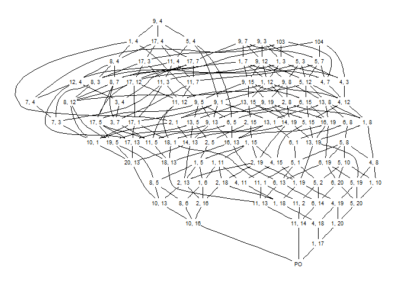

Congruence lattice for the Role structure.

```r
diagram(P_prA)
```

## Decomposition

```r
# decomposition of QA with the meet-complements in pi-relations
SsA <- decomp(S_A, pr_A, type="mca", reduc=TRUE)
```

```r
# clustering of strings with the three factors
SsA$clu
```

```
[[1]]
  C   F   K   A   D   G   L  CK  CD  CL  KD  KL  DC  DF  DK  GC CKD KDC DCK DCL
  1   1   1   2   3   4   2   1   4   1   4   1   3   3   3   4   4   4   3   3

[[2]]
  C   F   K   A   D   G   L  CK  CD  CL  KD  KL  DC  DF  DK  GC CKD KDC DCK DCL
  1   2   3   3   4   4   4   1   2   2   4   4   1   2   4   1   2   1   1   2

[[3]]
  C   F   K   A   D   G   L  CK  CD  CL  KD  KL  DC  DF  DK  GC CKD KDC DCK DCL
  1   1   2   1   1   1   2   2   1   2   2   2   1   1   2   1   2   2   2   2
```

The image matrices and partial order tables of the reduced semigroup structure are

```r
SsA$IM
```

```
[[1]]
  C A D G
C C C G G
A C A D G
D D D G G
G G G G G

[[2]]
  C F K D
C F F C F
F F F F F
K C F K D
D C F D D

[[3]]
  C K
C C K
K K K
```

```r
SsA$PO
```

```
[[1]]
  C A D G
C 1 0 1 1
A 1 1 1 1
D 0 0 1 1
G 0 0 0 1

[[2]]
  C F K D
C 1 1 0 0
F 0 1 0 0
K 1 1 1 1
D 1 1 0 1

[[3]]
  C K
C 1 0
K 1 1
```

And the hierarchy of relations in the homomorphic reduction of the three Factors with generator equations are

```r
scp <- list(lwd=2, fsize=20)
```

```r
# Factor 1
diagram(SsA$PO[[1]], scope=scp,
+    lbs=c("C,F,K","A","D","G"))
```

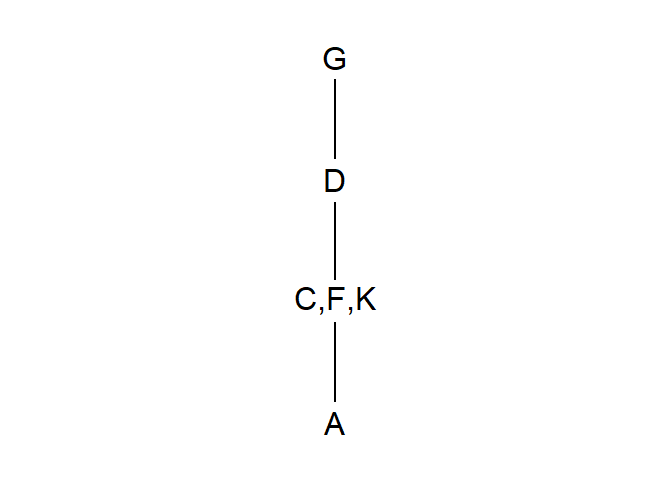

Factor 1 $QA_{103}$.

```r
# Factor 2
diagram(SsA$PO[[2]], scope=scp,
+    lbs=c("C","F","K","D,G,L"))
```

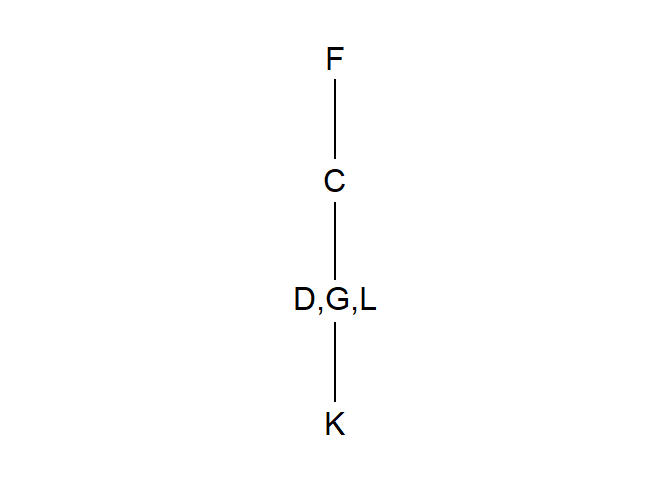

Factor 2 $QA_{104}$.

```r
# Factor 3
diagram(SsA$PO[[3]], scope=scp,
+    lbs=c("C,F,A","K"))
```

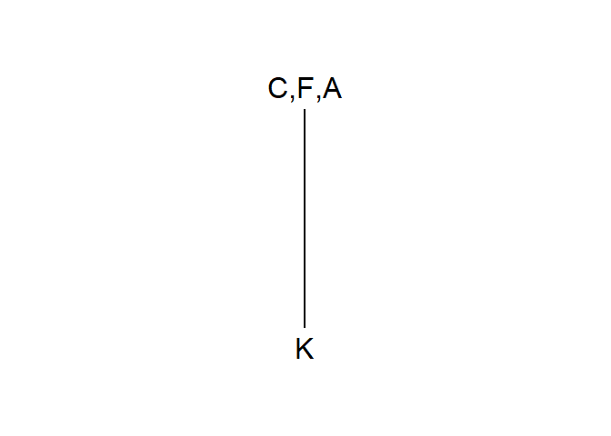

Factor 3 $QA_{25}$.

##### Content

- [Introduction – Monastery novices network](https://htmlpreview.github.io/?https://github.com/mplex/networks2021/blob/main/pres/Intro_plotting.html)
- [Elementary Algebraic Structures](https://htmlpreview.github.io/?https://github.com/mplex/networks2021/blob/main/pres/Algebraic_structures.html)
- [Role Structure in Multiplex Networks](https://htmlpreview.github.io/?https://github.com/mplex/networks2021/blob/main/pres/Role_structures.html)
- [Decomposition of Role Structures](https://htmlpreview.github.io/?https://github.com/mplex/networks2021/blob/main/pres/Decomposition.html)
- [Signed Networks](https://htmlpreview.github.io/?https://github.com/mplex/networks2021/blob/main/pres/Signed_networks.html)
- [Affiliation Networks](https://htmlpreview.github.io/?https://github.com/mplex/networks2021/blob/main/pres/Affiliation_networks.html)
- [Multilevel Networks](https://htmlpreview.github.io/?https://github.com/mplex/networks2021/blob/main/pres/Multilevel_networks.html)